# Proyecto Final

Curso IE0217 Estructuras abstractas y algoritmos para ingeniería - UCR Verano

David Chen-B82205 y José Pablo Porras-B86113

23/11/2021

# Uso de tweepy en la minería de datos y su representación

En este proyecto se tuvo como objetivo mostrar el dominio de manipulación de datos vistos en clase y en tiempos de estudio propio. Gracias a esto se pudo llegar a alcanzar tres grandes objetivos principales:

1. Mostrar el uso de tweepy para la obtención de datos de Twitter.
2. Mostrar el manejo de los datos obtenidos por medio de tweepy para su manipulación por medio de librerías de python.
3. Mostrar la representación de los datos obtenidos por medio de tablas o mapas.

### Tweepy

Para la extracción de los datos de este proyecto se utilizó tweepy con una cuenta de desarrollador que nos daba las claves de acceso a la API de Twitter. Que se ven de la siguiente forma:

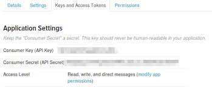

Una vez con esto obtenido podemos proseguir a la extracción de datos de Twitter

```python
#import json
#import numpy as np
import tweepy
import pandas as pd
#import matplotlib.pyplot as plt
#import matplotlib.pyplot as plt; plt.rcdefaults()
#import seaborn as sns
import re



consumer_key = "G3GrZyg7r89FCH96iurckOhlG"
consumer_secret = "KhqhetHDZwnunqI99XqsOtfRyJv0zmHXfY5SPDdgVx6jHkZKSJ"
access_token = "2963085141-SpdCreIunpWRqcDryBAyrykEYOiX1jMHHeGoMMT"
access_token_secret = "DUcW6OJJJgO8pmZO1r9XFeSYvEeBIafJKUmkPMM5a6A2I"

# Creating the authentication object
auth = tweepy.OAuthHandler(consumer_key, consumer_secret)
# Setting your access token and secret
auth.set_access_token(access_token, access_token_secret)
# Creating the API object while passing in auth information
api = tweepy.API(auth)


# The Twitter user who we want to get tweets from
name = "OVSICORI_UNA"
# Number of tweets to pull
tweetCount = 200

# Calling the user_timeline function with our parameters
results = api.user_timeline(id=name, count=tweetCount, tweet_mode="extended")

# Empty Array
```

```
## Unexpected parameter: id
```

```python
tweets = []
# for loop to get tweets
for tweet in results:
    # Appending the text of each tweet
    tweets.append(tweet.full_text)
    #print(tweet.full_text)
```

[figure not shown]

[figure not shown]

## Manejo de datos

Una vez corrido este código podemos extraer los datos de los tweets y guardarlos en un dataframe de la siguiente forma:

```python
# Making tweets a dataframe
tweets_df = pd.DataFrame(tweets)
print(tweets_df)
```

```
##                                                      0
## 0    2021-12-02 07:18:53.2, Mag: 3.52, Prof: 38.81 ...
## 1    2021-12-01 21:21:50.4, Mag: 3.4, Prof: 20.21 k...
## 2    2021-12-01 17:44:54.5, Mag: 4.57, Prof: 32.03 ...
## 3    2021-12-01 16:38:13.6, Mag: 3.5, Prof: 42.7 km...
## 4    2021-12-01 06:06:7.3, Mag: 3.39, Prof: 49.62 k...
## ..                                                 ...
## 195  2021-11-08 10:18:52.9, Mag: 2.25, Prof: 10.0 k...
## 196  2021-11-08 00:11:54.3, Mag: 3.72, Prof: 30.95 ...
## 197                  #ovsicori https://t.co/EIGvLGaGMk
## 198  2021-11-06 18:27:37.5, Mag: 2.53, Prof: 40.32 ...
## 199  2021-11-06 12:01:34.9, Mag: 4.16, Prof: 18.41 ...
##
## [200 rows x 1 columns]
```

Luego se manipula este mismo para poder separar cada palabra del tweet y guardarlo dentro de una columna

```python
# Splitting all the sentences into words
tweets_df= []
for tweet in tweets:
    tweets_df.append(tweet.split(" "))
#print (tweets_df)
```

Aparte a esto tambien se tiene el archivo datos.py el cual tiene una base de datos en un archivo .csv que contienen los datos de los cantones de Costa Rica y para visualizarlo se utiiza

```python
#import csv
#import pandas as pd

# Read data from csv file cantones.csv
def read_data(file_name):
    data = pd.read_csv(file_name, sep=";", encoding="utf-8", header=None)
    return data

# Making a dataframe with the data
def dataframe(data):
    df = pd.DataFrame(data)
    return df

# Set index of the dataframe
def set_index(df):
    df.set_index(0, inplace=True)
    return df
# Calling the function
data = read_data("cantones.csv")
df = dataframe(data)
df = set_index(df)
print (df)
```

```
##                      1            2
## 0
## Canton         Latitud     Longitud
## Abangares   10,2493051  -85,0221404
## Acosta       9,7417044  -84,2436381
## Aguirre      9,4130419  -84,0649764
## Alajuela    10,0173148  -84,2132869
## ...                ...          ...
## Turrubares   9,7475327  -84,5282903
## Upala       10,8681718  -85,1446055
## Valverde    10,1625862  -84,3151831
## Coronado    10,0760873  -83,9758294
## Zarcero       10,21888  -84,4174738
##
## [82 rows x 2 columns]
```

Una vez tenidos estos datos podemos visualizarlos en un un gráfico de barras y un mapa respectivamente.

### Gráfico de barras

Para dicho gráfico de barras lo que se tiene que hacer es primero ordenar los datos para poder usara la libreriía seaborn para poder graficarlo.

```python
# Removing the punctuation with regular expression
words = []
for tweet in tweets_df:
    for word in tweet:
        words.append(re.sub(r'[^\w\s]','',word))
#print (words)
```

Una vez con los datos sin signo de puentuación podemos proceder a ordenarlos y graficarlos:

```python
# Making it a dataframe
df = pd.DataFrame(words)
df = df[0].value_counts()
print (df)
```

```
## de                    598
## km                    382
## Sismocr               196
## temblorcr             196
## Mag                   196
##                      ...
## httpstcobK2JlPBZgA      1
## 011955                  1
## 4241                    1
## Pozo                    1
## httpstcoa1xBy7qhYv      1
## Name: 0, Length: 1040, dtype: int64
```

```
##    Provincias  Sismos
## 0    San José      22
## 1  Puntarenas     109
## 2  Guanacaste      42
## 3     Cartago       6
## 4       Limón      10
## 5    Alajuela       7
## 6     Heredia       0
```

[figure not shown]

```python
san_jose=words.count("José\novsicori")
puntarenas=words.count("Puntarenas\novsicori")
guanacaste=words.count("Guanacaste\novsicori")
cartago=words.count("Cartago\novsicori")
limon=words.count("Limón\novsicori")
alajuela=words.count("Alajuela\novsicori")
heredia=words.count("Heredia\novsicori")

provincias={"Provincias":["San José","Puntarenas","Guanacaste","Cartago","Limón","Alajuela","Heredia"],
            "Sismos":[san_jose,puntarenas,guanacaste,cartago,limon,alajuela,heredia]}

df1 = pd.DataFrame(provincias)
print(df1)

#plt.figure(figsize=(10,5))
#sns.barplot(x='Provincias', y='Sismos', alpha=0.8,data=df1.reset_index())
#plt.title('Sismos por provincias')
#plt.ylabel('Cantidad de sismos')
#plt.xlabel('Provincias')
#plt.show()
```

### Mapa

A la hora de hacer el mapa se tiene que hacer uso de la librería folium para poder graficarlo.

Por medio del siguiente código se puede ver el mapa de Costa Rica:

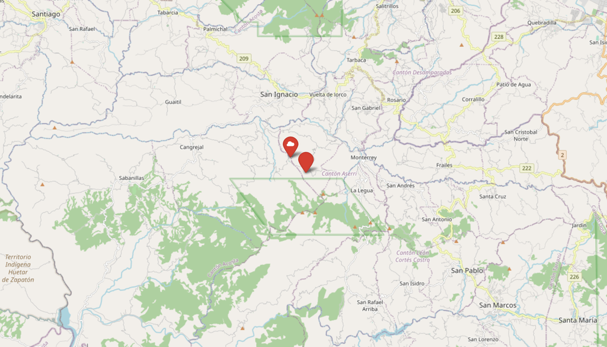

Mapa

```python
# Libraries to map the data
#import folium

# Creating a map
Latitud=9.74722222
Longitud=-84.14527778
canton = 'aserri'
x=9.75722999
y=-84.15527800
#map = folium.Map(location=[Latitud,Longitud ], zoom_start=12)
## Adding markers
#map.add_child(folium.Marker(location=[Latitud,Longitud], popup=canton, icon=folium.Icon(color='red' , icon='')))
## Adding markers
#map.add_child(folium.Marker(location=[x,y], popup=canton, icon=folium.Icon(color='red' , icon='cloud')))

# showing the map
#map.save('map.html')
```